# Data_Wrangling-Copy1

```python
# Import data library
import json
import gzip
import numpy as np
import pandas as pd
import re
```

```python
raw_data=[]
with gzip.open('ida_wrangling_exercise_data.2017-02-13.jsonl.gz', 'r') as f:
    for line in f:
        raw_data.append(json.loads(line.decode('utf-8')))
```

```python
table = pd.DataFrame(raw_data)
```

```python
table
```

|  | address | dob | email | id | name | phone | record_date | ssn |
| --- | --- | --- | --- | --- | --- | --- | --- | --- |
| 0 | {'zip': '83973', 'state': 'RI', 'street': '863... | 1971-06-30 | opark@hotmail.com | 01d68a4c598a45559c06f4df0b3d82cb | {'lastname': 'Dawson', 'middlename': 'Claire',... | 624-869-4610 | 2006-07-08T09:02:13 | xxx-xx-2412 |
| 1 | 20722 Coleman Villages\nEast Rose, SC 71064-5894 | 1965-09-09 | sperez@armstrong.com | 876ff718291d4397bb1e0477ceee6ad9 | {'lastname': 'Myers', 'firstname': 'Tamara'} | 1-594-462-7759 | 2009-03-28T20:22:57 | xxx-xx-8025 |
| 2 | {'zip': '73125', 'state': 'UT', 'street': '667... | 1993-04-12 | uortiz@gmail.com | 81753097bf7e4e2085982f422bdb9cda | {'lastname': 'Alexander', 'firstname': 'Jamie'} | 472.218.5065x389 | 2016-08-30T20:31:39 | xxx-xx-0568 |
| 3 | 0932 Gomez Drives\nLeefort, MD 46879-3166 | 1977-04-14 | palmerdiane@yahoo.com | 2c2f7154b80f40ca80d08c5adc54ea45 | {'lastname': 'Garcia', 'middlename': 'Alexis',... | 1-663-109-4460x1080 | 2001-02-15T18:50:35 | xxx-xx-9825 |
| 4 | {'zip': '42483', 'state': 'ME', 'street': '158... | 1970-03-19 | nancymaxwell@gmail.com | 4f5263f339694d068e17ee7fdbb852b8 | {'lastname': 'Rodriguez', 'firstname': 'Jennif... | 233-423-3823 | 2014-06-21T14:36:01 | xxx-xx-9104 |
| 5 | {'zip': '02398', 'state': 'AR', 'street': '461... | 1989-12-23 | peterkhan@serrano.net | e615757bb70e4c9e8ec532f22a764a3e | {'lastname': 'Meadows', 'firstname': 'Keith'} | 686-305-8557x0623 | 2012-03-02T10:37:14 | xxx-xx-4652 |
| 6 | 9524 Danielle Burg Apt. 849\nNorth Vickistad, ... | 1983-05-09 | laurenreilly@lopez-hurst.com | 60880b0bcf614ccda8688409ee9d8db3 | {'lastname': 'Garcia', 'firstname': 'Shane'} | 721-135-6630 | 2013-01-19T12:17:21 | xxx-xx-5597 |
| 7 | 407 Patrick Shoal\nWilliamsshire, VI 49526 | 1989-10-05 | wallaceheather@obrien-richardson.com | 357cbf915fdb46dfa76c7bd3ea10feff | {'lastname': 'Bell', 'middlename': 'Lee', 'fir... | 528-480-7488x60984 | 2004-03-03T07:35:59 | xxx-xx-7244 |
| 8 | {'zip': '70997-3753', 'state': 'CT', 'street':... | 1987-06-24 | michael18@yahoo.com | bbf4acd3660c4ba1803f396d789e538a | Morgan Morris | 09316674472 | 2000-03-07T03:55:21 | xxx-xx-7034 |
| 9 | NaN | 1980-03-20 | erinsanford@garcia.com | 3422bcb95ad6454f8348087ba25902f0 | Bernard Wilkerson | 196-454-2484 | 2016-11-29T21:01:43 | xxx-xx-0866 |
| 10 | {'zip': '77615', 'state': 'WY', 'street': '017... | 1989-10-23 | zimmermanbrian@gmail.com | 156fe664697b49349ccdc0d0ff054a33 | {'lastname': 'Davis', 'firstname': 'Amanda'} | 443.378.1619x08587 | 2015-06-04T20:14:05 | xxx-xx-2246 |
| 11 | 395 Anna Roads Apt. 613\nAlexandershire, FL 22077 | 1977-03-09 | betty85@yahoo.com | 53a795877fe24c09a0a950e9febf9758 | {'lastname': 'Guerra', 'firstname': 'Adrian'} | +74(2)6173978109 | 2001-05-04T02:12:57 | xxx-xx-1050 |
| 12 | {'zip': '15884', 'state': 'MN', 'street': '568... | 1977-09-26 | dustin06@gmail.com | b75dda689be842a8ad6bb52f3783cabc | Casey Haas | +62(2)9284019429 | 2016-09-17T12:06:53 | xxx-xx-4247 |
| 13 | {'zip': '68916', 'state': 'MO', 'street': '045... | 1962-08-02 | scottboyd@hotmail.com | 43989614a5d84a07b64f5f397d6e8079 | {'lastname': 'Hall', 'middlename': 'Gabrielle'... | NaN | 2009-09-07T00:32:29 | xxx-xx-9110 |
| 14 | {'zip': '15956-9706', 'state': 'VI', 'street':... | 1975-12-12 | NaN | 04d41c1e5ab748f8aeeacff3e9536c9c | Barbara Harris | (683)392-8521 | 2012-08-09T01:40:26 | xxx-xx-8164 |
| 15 | 8439 Greer Center Suite 843\nNorth Ryanland, W... | 1989-06-16 | morrisellen@yahoo.com | b195eb79b7ce427684442617f98cca5a | Crystal Bennett | 494.161.8907x4812 | 2003-11-28T10:39:33 | xxx-xx-8301 |
| 16 | {'zip': '03505-6647', 'state': 'NC', 'street':... | 1983-11-13 | NaN | 2a60628968fd4659950b12f1a95d7dfb | Eric Cain | (406)239-6513x03040 | 2005-02-02T10:25:08 | NaN |
| 17 | 15131 Alicia Islands Suite 074\nSouth Javier, ... | 1985-11-03 | ldonaldson@yahoo.com | cf67ba8b002f4feca95445ecb4698d2f | {'lastname': 'Trevino', 'middlename': 'Gabriel... | 504-014-4601x674 | 2009-03-20T11:42:09 | NaN |
| 18 | NaN | 1965-04-12 | mcdonaldchristopher@morrison.info | 81bf075d949c45f1a718988c2990fe7b | {'lastname': 'Davis', 'middlename': 'Charles',... | 532-944-5053 | 2003-05-01T16:37:31 | xxx-xx-4282 |
| 19 | 4796 Norton Summit\nBillton, MO 80361-8343 | 1948-02-18 | andrewsjames@williams.net | 5f4dceaff4024e10af09897e874e7ca5 | Cindy Banks | 880.073.4374x9017 | 2009-07-08T11:02:46 | xxx-xx-7855 |
| 20 | {'zip': '21960', 'state': 'LA', 'street': '392... | 1973-12-29 | NaN | c2bbd72101e74c288f0944200e4afaf1 | {'lastname': 'Chambers', 'firstname': 'Lindsay'} | 685-597-1056x1053 | 2004-03-27T09:22:28 | xxx-xx-1795 |
| 21 | {'zip': '91147', 'state': 'IA', 'street': '873... | 1989-05-03 | jonesmatthew@yahoo.com | 14b0426544904bdfbf16c29037e1eea2 | {'lastname': 'Taylor', 'middlename': 'Angela',... | 02087793627 | 2002-01-01T20:47:36 | xxx-xx-7938 |
| 22 | 78000 Bryan Plaza Suite 275\nSouth Matthewburg... | 1955-01-07 | zunigaglen@gmail.com | 6dc4e84b29bb43afbe9ef9bae900ae2e | {'lastname': 'Hall', 'firstname': 'Amy'} | 217.917.9874x603 | 2014-10-08T02:49:20 | xxx-xx-2641 |
| 23 | 31979 Wendy Hollow Suite 911\nNew Jeremy, VI 0... | 1958-05-18 | greencathy@gaines.org | af7468b4d2a74473bcd199f54914e0cc | Thomas Butler | 217-008-6889 | 2014-12-20T08:29:17 | xxx-xx-6296 |
| 24 | NaN | 1979-05-25 | johnny69@robinson.com | baaaee5fd0a043cbb48832979679d5b9 | {'lastname': 'Clark', 'firstname': 'Christopher'} | 353-048-3198x85710 | 2003-11-27T19:20:10 | xxx-xx-0895 |
| 25 | 6063 Sarah Passage\nGaryview, IA 04420 | 1947-07-08 | mccartysheri@gmail.com | 6d116451a92c4898bd6dad55432e6e54 | {'lastname': 'Sanford', 'firstname': 'Melissa'} | +84(7)5628190571 | 2006-01-25T19:03:04 | xxx-xx-6695 |
| 26 | {'zip': '89500-9726', 'state': 'MT', 'street':... | 1950-05-08 | NaN | f27f7fdf6462424c9b396e9c90be4a5c | {'lastname': 'Chapman', 'firstname': 'Crystal'} | 1-290-722-3334x15776 | 2002-09-20T23:16:00 | xxx-xx-5562 |
| 27 | {'zip': '25315', 'state': 'MN', 'street': '385... | 1950-10-05 | NaN | 5013fa1de8994aa8b9e50b39bcb745d8 | {'lastname': 'Gilbert', 'firstname': 'Mallory'} | 809-572-1158x84716 | 2014-02-26T07:30:41 | xxx-xx-4379 |
| 28 | 0597 Ann Shore\nNorth Mitchell, OK 36332 | 1991-01-28 | jessicarobinson@humphrey-rogers.biz | 2466be83feab49e298e7547d6a3a9d80 | {'lastname': 'Hutchinson', 'firstname': 'Eliza... | 02996289892 | 2016-06-19T09:46:51 | xxx-xx-6533 |
| 29 | 90745 Stephanie Run\nNew Barbarahaven, AZ 72722 | 1980-08-30 | anita93@harris.com | e87dc8df69a64b43b0bc1e3afbadfdc9 | {'lastname': 'Reed', 'middlename': 'Samuel', '... | 1-688-873-4927x90906 | 2007-11-24T00:34:09 | xxx-xx-4715 |
| ... | ... | ... | ... | ... | ... | ... | ... | ... |
| 149970 | {'zip': '23518', 'state': 'AZ', 'street': '868... | 1958-08-22 | tommy14@bass.com | 7f94ec1bd5d24e9cba49a94cbd84f61d | Mary Everett | 453.670.4394x245 | 2013-09-24T08:03:50 | xxx-xx-8345 |
| 149971 | {'zip': '72024-8777', 'state': 'MA', 'street':... | NaN | samanthalewis@west.com | 042c0690ed8c4153a22f5af690805199 | {'lastname': 'Turner', 'firstname': 'Nathaniel'} | +66(7)4767380794 | 2003-10-08T12:45:35 | xxx-xx-2982 |
| 149972 | {'zip': '16068-9123', 'state': 'KS', 'street':... | 1971-05-09 | jaimeaguilar@dickson.net | ccc8a588dbea4546872828387265220f | Nathan Hill | (721)466-3984 | 2001-06-28T22:58:03 | xxx-xx-4842 |
| 149973 | {'zip': '88689-3634', 'state': 'WV', 'street':... | 1954-12-22 | danielrobinson@daniels.com | 5c86a5a7b6b24da3a7ef7e255857a753 | Olivia Fisher | (426)129-4414 | 2006-05-22T12:34:16 | xxx-xx-4231 |
| 149974 | NaN | 1961-05-24 | jchurch@anderson.com | be32047190ba486eaf73fd2ab646e2f1 | {'lastname': 'White', 'middlename': 'Tiffany',... | 984-484-5527x89698 | 2011-05-24T06:04:15 | xxx-xx-4486 |
| 149975 | NaN | 1979-06-06 | monique48@hotmail.com | 005a0ddf497249ad808e5f4948f9b361 | {'lastname': 'Vincent', 'firstname': 'Victoria'} | 291-902-8427 | 2002-12-25T18:36:49 | xxx-xx-1326 |
| 149976 | 9218 Gomez Mountain\nJohnsonville, WY 81584-4328 | 1956-06-18 | robertpowers@gmail.com | ab44de3aad3f411fb28ab69f3671da53 | Dean Johnson | 974-236-6898 | 2011-08-31T07:58:55 | xxx-xx-7976 |
| 149977 | {'zip': '18659-8678', 'state': 'SC', 'street':... | NaN | riverskaren@yahoo.com | d18b90ecd71a42849e822dceb47e668c | Gail Hernandez | 227-931-7153 | 2008-02-29T19:10:28 | xxx-xx-1413 |
| 149978 | {'zip': '01607', 'state': 'GU', 'street': '307... | 1964-05-31 | nicholasday@yahoo.com | 461bc49b05d94f378701893ca05f6bc5 | {'lastname': 'Bryant', 'firstname': 'Paul'} | 487-465-1515x963 | 2004-01-23T06:43:23 | xxx-xx-5653 |
| 149979 | 89099 Sanchez Canyon Suite 382\nWest Sarah, LA... | 1963-06-15 | aaron87@davis.biz | 2482c95b01424aaf9dd972b14e0e43b7 | Kelsey Brady | +41(3)6772802266 | 2016-05-15T22:42:58 | xxx-xx-4444 |
| 149980 | {'zip': '29047', 'state': 'MI', 'street': '085... | 1975-06-09 | leehill@gonzalez.com | a3b8062b955547568cc4a45fe198f36e | Bradley Scott | 1-871-965-8793x66131 | 2010-03-24T17:32:54 | xxx-xx-1457 |
| 149981 | 034 Andrea Run\nThomasland, AL 19551-9506 | 1947-12-03 | NaN | 802723aed72e47ebad7a9ead2fddbb33 | {'lastname': 'Simmons', 'middlename': 'Brittan... | 01003458292 | 2005-04-09T06:28:15 | NaN |
| 149982 | 2179 Tiffany Oval Suite 149\nMaddoxville, GA 1... | 1962-02-13 | fhall@faulkner.com | c68c972a2c4d4747ad31cc78cfbeba11 | {'lastname': 'Watson', 'firstname': 'James'} | (748)291-7708 | 2002-05-22T19:47:51 | xxx-xx-6078 |
| 149983 | {'zip': '76119', 'state': 'ID', 'street': '472... | 1954-09-11 | dcohen@wilson.net | 3f116158632640df9247f43a6db02827 | {'lastname': 'Blankenship', 'middlename': 'Jer... | 618.889.4227 | 2014-11-01T16:06:54 | xxx-xx-9209 |
| 149984 | 828 Wilson Shore Apt. 874\nHillfurt, UT 58863 | 1978-04-25 | debramoody@medina.com | ed719d00458c4e79a29c6da7113ff9cd | {'lastname': 'White', 'firstname': 'Haley'} | (838)809-6942x833 | 2002-04-07T16:15:42 | xxx-xx-2829 |
| 149985 | 239 Wayne Harbors Suite 621\nMalloryfort, UT 6... | 1967-03-16 | holawrence@maldonado-winters.com | 1598b618efdd4976a16a11d6a9da2b90 | {'lastname': 'Gutierrez', 'middlename': 'Edwar... | 391-239-2565x11047 | 2008-11-11T16:38:15 | xxx-xx-3821 |
| 149986 | 033 Julia Avenue\nCarolynbury, VT 09845-4107 | 1954-11-27 | jessicabuchanan@herrera.com | 16dbe39958684d839077eaec2bde3e44 | {'lastname': 'Schwartz', 'middlename': 'Savann... | 1-248-608-6600x091 | 2006-01-22T20:16:43 | xxx-xx-3674 |
| 149987 | 31640 Reed Knolls Apt. 548\nMelissaside, GA 25615 | 1973-06-13 | tracey09@morris-hawkins.com | 44158a2a26534ba7b432216f42792388 | {'lastname': 'Gonzales', 'middlename': 'Edward... | +82(6)2211988571 | 2012-09-02T07:12:56 | xxx-xx-8861 |
| 149988 | NaN | 1969-08-12 | NaN | 36bde729e51342d9a0471e15b106d791 | {'lastname': 'Sullivan', 'middlename': 'Timoth... | 1-916-400-8688x853 | 2010-03-20T15:22:38 | xxx-xx-9328 |
| 149989 | 044 Stone Avenue\nMarialand, CT 96606 | 1955-03-11 | paynelaura@wells.com | 2d41d96a1f94435e9e5a3e44ad6f42f7 | Mariah Wilson | +02(0)3284519718 | 2002-06-26T05:22:08 | xxx-xx-6638 |
| 149990 | {'zip': '35034', 'state': 'AZ', 'street': '622... | NaN | bowersjulie@gonzalez.biz | 8ff139627d4e4e8bbacbadb81cff9128 | {'lastname': 'Alvarez', 'middlename': 'Stacey'... | +18(9)0609811091 | 2001-03-28T20:48:09 | xxx-xx-8014 |
| 149991 | 40839 Francis Turnpike\nNorth Brandon, IN 04334 | 1948-02-21 | baileytara@gmail.com | 3df7bf5940f6434f8e4fcce870f91b51 | Sue Oconnell | 903-410-7160x0983 | 2015-06-03T19:29:22 | xxx-xx-4399 |
| 149992 | 518 Bailey Plains Suite 709\nWest Mariaview, M... | 1984-05-31 | NaN | e73560393d62438ca04f949ac7014c32 | {'lastname': 'Sloan', 'firstname': 'Ryan'} | 1-465-235-2798 | 2006-07-09T16:31:55 | xxx-xx-8196 |
| 149993 | 244 Kathleen Stravenue\nRyanmouth, SD 88692-7289 | 1967-08-29 | troyparker@williams-myers.com | d6485b724d4e496f9ae925c874691f22 | {'lastname': 'Turner', 'firstname': 'Ray'} | +16(3)5548805840 | 2012-10-19T20:32:49 | xxx-xx-7774 |
| 149994 | NaN | 1969-02-24 | lovelisa@hotmail.com | 9f567315891c4cf896b6582c79108e05 | Anna Davis | 1-724-393-5084 | 2014-06-30T10:53:03 | xxx-xx-7877 |
| 149995 | 52805 Higgins Harbor\nJessicamouth, SC 83621-8672 | 1948-08-18 | NaN | 91b1d3cbcb794e49a41cfdfe66ff931d | {'lastname': 'Mejia', 'middlename': 'Curtis', ... | 704-719-8698 | 2016-09-24T17:00:36 | xxx-xx-9311 |
| 149996 | {'zip': '41818', 'state': 'GA', 'street': '231... | 1988-10-28 | NaN | af070fd4476946e6b4755232d8ec8252 | {'lastname': 'Solis', 'firstname': 'Emily'} | (548)476-4285x0779 | 2014-11-17T01:50:15 | xxx-xx-5319 |
| 149997 | 8772 Evans Mill\nThomasborough, AK 26835-9457 | NaN | daisy78@johnson-johnson.info | e8cddfe3494e486aae6735e027fd6c8d | Anna Walter | (926)119-0532x51870 | 2006-08-16T21:40:19 | xxx-xx-0710 |
| 149998 | {'zip': '17785', 'state': 'UT', 'street': '858... | 1977-11-10 | hilledward@gutierrez.net | b47fedaa20bd428fb674aeb8db0ba1cc | Gary Rodriguez | 670-853-5186 | 2012-03-29T18:42:39 | xxx-xx-6767 |
| 149999 | 3178 Mary Plains\nKeithville, VT 34029-5102 | 1987-11-17 | jessicalewis@carroll-martinez.com | 6081948439244760865cf6c21ad77248 | {'lastname': 'Johnson', 'firstname': 'Alex'} | 791-310-0485 | 2004-05-29T18:44:26 | xxx-xx-7983 |

150000 rows × 8 columns

```python
uique_named_fields = set()
uique_named_fields |=set(table.columns.values.tolist())
```

```python
def explore_nested_fields(table, input_features):
    temp_keys =set()
    for feature in input_features:
        temp_keys2 = set()
        for line in table[feature]:
                if(isinstance(line, dict)):
                    temp = set(line)
                    temp_keys2 |= temp

        for key in temp_keys2:
            temp_keys.add(str(feature)+'.'+str(key))
    return temp_keys
```

# Output for question 1:

```python
input_features=['name','address']
nested_fields= explore_nested_fields(table, input_features)
uique_named_fields|=nested_fields
print(sorted(uique_named_fields))
```

```
['address', 'address.city', 'address.state', 'address.street', 'address.zip', 'dob', 'email', 'id', 'name', 'name.firstname', 'name.lastname', 'name.middlename', 'phone', 'record_date', 'ssn']
```

## Quantitative analysis

Answer the following questions for each field in your list from question 1.

- What percentage of the records contain the field?
- What are the five most common values of the field?

```python
def percentage_nested_fields(table, uique_named_fields):
    count_name =dict()
    input_features= set(table.columns.values.tolist())
    for feature in input_features:
        for line in table[feature]:
                if(isinstance(line, dict)):
                    temp = set(line)
                    for i in temp:
                        key = feature+'.'+str(i)
                        if(key in count_name.keys()):
                            count_name[key]+=1
                        else:
                             count_name[key]=1
                else:
                    if(pd.isnull(line)!=True):
                        if(feature in count_name.keys()):
                            count_name[feature]+=1
                        else:
                            count_name[feature]=1
    return count_name
```

```python
from pprint import pprint

named_field_counts=percentage_nested_fields(table, uique_named_fields)
pprint(named_field_counts)
```

```
{'address': 75193,
 'address.city': 61233,
 'address.state': 61233,
 'address.street': 61233,
 'address.zip': 61233,
 'dob': 143874,
 'email': 130880,
 'id': 150000,
 'name': 43058,
 'name.firstname': 105004,
 'name.lastname': 105004,
 'name.middlename': 43669,
 'phone': 140261,
 'record_date': 150000,
 'ssn': 142444}
```

**What percentage of the records contain the field?**

**Discussion**

- The result shows that each json object/input item has an ID
- Additionally, each input item has recored date.
- `{street, city, state, zip}` always show together, if say the correpsonding address is written in a nested field
- `{firstname, lastname}` always show together, if the name is not shown together in as a single string

### Result for Question 2.1

```python
n= len(raw_data)
named_field_percentage=dict()
print("name & corresponding percentage:")
for k, v in named_field_counts.items():
    named_field_percentage[k]=(float(v)/n)*100
    print("%s : %.1f%% " % (k, named_field_percentage[k]))
    #print(str(k)+' : ' + '%.2f' %  named_field_percentage[k]+'%'))
```

```
name & corresponding percentage:
record_date : 100.0%
ssn : 95.0%
name : 28.7%
name.middlename : 29.1%
dob : 95.9%
address.state : 40.8%
name.firstname : 70.0%
id : 100.0%
phone : 93.5%
email : 87.3%
address.zip : 40.8%
address : 50.1%
address.city : 40.8%
address.street : 40.8%
name.lastname : 70.0%
```

- First sort the frequency and name dist-object
- Output the top 5 values of the field

### Result for Question 2.2

```python
from operator import itemgetter
top_common_name_values=[]
for key, value in sorted(named_field_counts.items(), key = itemgetter(1), reverse = True):
    top_common_name_values.append((key, value))
for i in range(5):
    print(top_common_name_values[i])
```

```
('record_date', 150000)
('id', 150000)
('dob', 143874)
('ssn', 142444)
('phone', 140261)
```

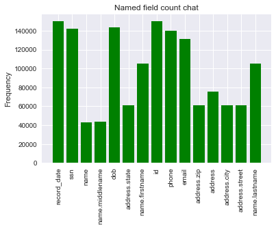

```python
import matplotlib.pyplot as plt
import seaborn as sns

sns.set()
x_labels = [i for i in named_field_counts.keys()]
y = [i for i in named_field_counts.values()]
x = range(len(x_labels))
plt.bar(x, y, color='green', align='center')
plt.title('Named field count chat')
plt.ylabel('Frequency')
plt.xticks(x, x_labels, rotation='vertical')
plt.show()
```

### Question 3

**How many distinct first names appear in this data set?**

- As previous result of field name shows that first name is only possible shown where key = `name` or `name.firstname`
- When `key` == `name`, the name string is split by space, and the first half is saved as the first name
- When `key` == 'name.firstname', then we simply save it into predefined set

```python
def street_names_area_firstname(json_files):
    firstnames=set()
    street_names=set()
    phone_area=[]
    #phone_sec = set()
    test=[]
    for line in json_files:
        for k,v in line.items():
            if '{' in str(v):
                temp_street=dict()
                for k1, v1 in v.items():
                    if '{' in str(v1):
                        for k2, v2 in v1.items():
                            temp = k+'.'+ k1 + '.'+ k2
                            if(temp=='name.firstname'):
                                firstnames.add(v1)
                    else:
                        if(str(k)=='address'):
                            #print(temp_street)
                            temp_street[k1]=str(v1)
                        temp = k+'.'+k1
                        if(temp=='name.firstname'):
                            firstnames.add(v1)

                if(len(temp_street)==4):
                    #street_names.add(temp_street['street']+'\n'+temp_street['city']+', '+temp_street['state'] +' '+temp_street['zip'])
                    temp_street1=re.findall('\s(.+)',temp_street['street'])
                    street_names.add(temp_street1[0])
            else:
                if(str(k)=='name'):
                    temp = re.split('\s+', str(v))
                    firstnames.add(temp[0])

                if(str(k)=='address'):
                    temp_street = re.split(r'[\n\r]+', str(v))
                    #if(temp_street!=[]):
                    temp_street1=re.findall('\s(.+)',temp_street[0])
                    street_names.add(temp_street1[0])

                # process to get phone area code
                if(str(k)=='phone'):
                    temp = re.split(r'\s|-|\.', str(v))
                    #phone_sec.add(len(temp))
                    if(len(temp)==3):
                        #Assume it's within US, and we add 1 to 1
                        phone_area.append(temp[0])
                    if(len(temp)==4 ):
                        if(temp[0]=='1'):
                            phone_area.append(str(temp[1]))
                        else:
                            test.append(temp[0])
                    if(len(temp)==1):
                        if(len(str(v))==9):
                            phone_area.append(str(v)[0:3])
                        #phone_count.append(len(str(v)))

    return firstnames, street_names, phone_area
```

## Result for Question 3

```python
firstnames, street_names, phone_area = street_names_area_firstname(raw_data)
print("Number of unique first name: ", len(firstnames))
```

```
Number of unique first name:  695
```

### Question 4

**How many distinct street names appear in this data set? Explain your procedure for identifying distinct street names**

Street names can be derived from two senarios:

1) When there is a `key` equal to `address`, then we need to extract **street name** from a complete address by removing house number, Apt. Number and Suite Number

2) Similarily, when the 'key' is equal to 'address.street', we add it to output

3) Once we got the "raw street name", we further remove Suite and Apt. numbers from it

**Further improve**: I noticed that some of the street address doesn't show as traditional street address. In instead, it includes PBox which can be further studied to improve the accuracy.

```python
street_names_unique=set()
noise =['Apt.', 'Suite']
for i in street_names:

    index = i.find('Apt.')
    if index>=0:
        tem = i[0:index]

        street_names_unique.add( re.sub( '\s+', ' ', tem ).strip())
    else:
        index = i.find('Suite')
        if(index>=0):
            tem = i[0:index]
            street_names_unique.add( re.sub( '\s+', ' ', tem ).strip())
        else:
            street_names_unique.add(i)
```

## Result for Question 4

```python
len(street_names_unique)
```

```
86124
```

## Question 5

**What are the 5 most common US area codes in the phone number field? Explain your approach to identify the US area codes in this data set**

**Approach**

1) Find the field name of `phone`, add then focus on its corresponding value

2) Split the phone number based on `-` or `.`, then we will get the following result:

```
- 3 element splits: we use the first element as the area code

- 4 element splits: if the national code is equal to 1, then we treated it as a US area code

- 2 element splits: Which can be further studied

- 1 element splits: Check if its length is equal to 9 or not, if yes, then we simply extract the first 3 digital numbers
```

**Further Improvement**: the structure of phone number can be further studied. The US area codes from this exercise can actually be compared tested using API to check if the area code is valid or not

```python
phone_area_count=dict()
for i in phone_area:
    if i in phone_area_count.keys():
        phone_area_count[i]+=1
    else:
        phone_area_count[i]=1

top_common_area_values=[]
for key, value in sorted(phone_area_count.items(), key = itemgetter(1), reverse = True):
    top_common_area_values.append((key, value))
```

## Result for Question 5

```python
top_common_area_values[0:5]
```

```
[('947', 118), ('111', 117), ('574', 115), ('112', 114), ('960', 113)]
```